# Exercise 10

# 3) Hirarchical Clustering with different thresholds for quality-based cell filtering

```r
startTime = proc.time()
```

## Load the data

```r
sce = readRDS("pbmc-sce.RDS")
sce
```

```
class: SingleCellExperiment
dim: 36601 10194
metadata(1): Samples
assays(1): counts
rownames(36601): ENSG00000243485 ENSG00000237613 ... ENSG00000278817
  ENSG00000277196
rowData names(3): ID Symbol Type
colnames: NULL
colData names(3): Sample Barcode cellType
reducedDimNames(0):
mainExpName: NULL
altExpNames(0):
```

Optionally subsample 2000 cells to reduce runtime

```r
set.seed(38)
sce = sce[ , sample(1:ncol(sce), size = 2000, replace = FALSE)]
```

The cell type abundandances are

```r
cd = as.data.frame(colData(sce))
ggplot(cd, aes(x=cellType)) + geom_bar() +
   scale_fill_manual() + theme(axis.text.x = element_text(angle = 45, vjust = 1, hjust=1))
```

[output not shown]

## Modify the quality-based cell filtering to remove the low quality cells that could not be assigned

Compute quality scores

```r
isMito <- grepl("^mt-", rowData(sce)$Symbol, ignore.case=TRUE)

sce <- addPerCellQC(sce, subsets=list(Mito=isMito), percent_top=100,
                    detection_limit=0, BPPARAM=BPPARAM)
```

Filter by quality

```r
qc.lib <- isOutlier(sce$sum, log=TRUE, type="both",)
qc.nexprs <- isOutlier(sce$detected, log=TRUE, type="both")
qc.mito <- isOutlier(sce$subsets_Mito_percent, type="both")
qc.top <- isOutlier(sce$percent.top_100, type="both")

discard <- qc.lib | qc.nexprs | qc.mito | qc.top

DataFrame(LibSize=sum(qc.lib), NExprs=sum(qc.nexprs),
          MitoProp=sum(qc.mito),
          TopProp=sum(qc.top), Total=sum(discard))
```

```
DataFrame with 1 row and 5 columns
    LibSize    NExprs  MitoProp   TopProp     Total
  <integer> <integer> <integer> <integer> <integer>
1       110        68       149        11       182
```

```r
sce$discard = discard

sceFilt = sce[ , !sce$discard]
minCellsExpressed = 6 #Edited
isExpressed <- Matrix::rowSums(counts(sceFilt) >= 1) >= minCellsExpressed
sceFilt = sceFilt[isExpressed, ]
```

Normalize

```r
sceFilt = logNormCounts(sceFilt)
```

Compute reduced dimension representation

```r
set.seed(38)
dec <- modelGeneVarByPoisson(sceFilt, BPPARAM=BPPARAM)
topGenes <- getTopHVGs(dec, n = 2000)
sceFilt <- runPCA(sceFilt, subset_row=topGenes, BPPARAM=BPPARAM)
sceFilt <- runUMAP(sceFilt, dimred="PCA", BPPARAM=BPPARAM)
```

```r
set.seed(100)
clust.hier <- hclust(dist(reducedDim(sceFilt, "PCA")), method="complete")
clust.hier <- cutree(clust.hier,k=15)
table(clust.hier)
```

```
clust.hier
  1   2   3   4   5   6   7   8   9  10  11  12  13  14  15
631 301 139  99 592  16  22   3   2   5   1   1   3   2   1
```

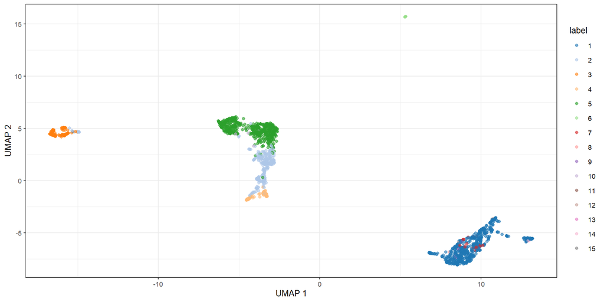

```r
colLabels(sceFilt) <- factor(clust.hier)
plotReducedDim(sceFilt, "UMAP", colour_by="label")
```

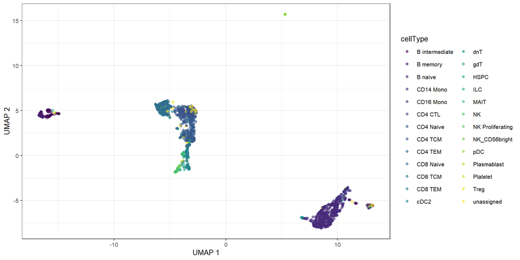

```r
plotReducedDim(sceFilt, "UMAP", colour_by="cellType")
```

Agreement of clusters with cell types

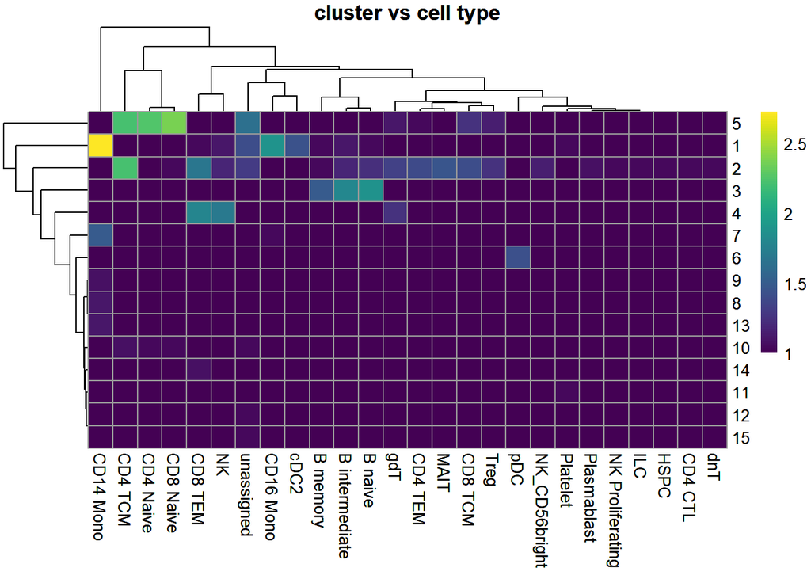

```r
tab <- table(sceFilt$label, sceFilt$cellType)
phm <- pheatmap(log10(tab+10), main="cluster vs cell type",
    color=viridis::viridis(100), silent=FALSE)
phm
```

## Result

Sensitivity and specificity of low quality cell detection

```r
mean(sce$discard[sce$cellType == "unassigned"])
```

```
[1] 0.5488722
```

```r
mean(!sce$discard[sce$cellType != "unassigned"])
```

```
[1] 0.9416176
```

Agreement of clustering and cell type

```r
mclust::adjustedRandIndex(sceFilt$label,sceFilt$cellType)
```

```
[1] 0.5115546
```

Runtime in seconds

```r
paste(signif((proc.time() - startTime)[ "elapsed"], digits=4), "s")
```

```
[1] "21.11 s"
```